# Support Vector Machines

[benjburgess.github.io](https://benjburgess.github.io/)

[Support Vector Machines](https://benjburgess.github.io/data/index/svm)

# Introductory Tutorial

## Introduction

As I’ve detailed in the [introduction to support vector machines (SVMs)](https://benjburgess.github.io/svm), SVMs are a machine learning tool which can be used to classify data into two or more different groups. Outlined below is an example of how an SVM approach can be applied to a relatively simple dataset. For this example, we shall be attempting to build a SVM which is capable of accurately classifying two species based upon their length (in millimetres) and their weight (in kilograms). Here, for simplicity, our species are simply ‘A’ or ‘B’. Here, each data point corresponds to an individual of either species ‘A’ or ‘B’ and the corresponding weight and length of that individual.

Throughout this tutorial, code chunks will have a blue background and output will have a green background. This tutorial is meant to be a relatively simple example of SVMs. For an example of SVMs with more complex data, see the [Advanced Tutorial on SVMs](https://benjburgess.github.io/i/SVM_radial).

## Packages and set.seed()

Firstly, we need to install the various packages we need for this tutorial. If any of these packages are not installed in your local machine, they can be installed via the `install.packages()` function. We will also set the seed for this code, with this simply to allow reproducibility of our results.

```r
library(ggplot2)
library(scales)
library(caret)
library(caTools)

set.seed(285)
```

## Data

For this tutorial we are going to generate our own data for simplicity. The set.seed() function above means that the results should be replicable across any machine. Firstly, we’ll specify the number of data points in our dataset (`number_data`) and the `split` of the dataset between the two different species. For this example, we’ll use a dataset containing 5000 data points, with there being an equal number of data points for species A and B.

Following this we’ll then generate the data for the length and weight of these species using the following code.

```r
number_data <- 5000

split <- 0.5


#Code to generate our data.

df <- data.frame(species = factor(c(rep("A", number_data*split), rep("B", number_data*(1-split)))))

df$length <- c(rnorm(number_data*split, 650, 75), rnorm(number_data*(1-split), 500, 50))

df$weight <- c(rnorm(number_data*split, 0.1, 0.025), rnorm(number_data*(1-split), 0.175, 0.035))

# Note that this could be editted for differing dataset, though there is no need to worry about these numbers for this example.
```

The next thing we need to do at this stage is split our dataset into two components, namely train and test datasets. For our analyses we will build our SVM using the train dataset, before finally testing our model using the test dataset. The test dataset should be *locked away* for the duration of our training stage as otherwise our results or actions could potentially be biased by our knowledge of the test data. This is turn could lead to the SVM being biased and potentially meaning that we think our model has a higher accuracy than it actually does.

Here, we will be using 70% of our data to train the SVM, and the other 30% of the data to test the model. A 70/30 is a fairly common way to split the data; however, other splits (e.g., 80/20; 67/33) could also be used.

To split our dataset, we will use the following code.

```r
split_determined  <- sample.split(df$species, SplitRatio = 0.7)
df.train <- df[split_determined,]
df.test  <- df[!split_determined,]
```

We can plot our dataset from the train dataset using the following code.

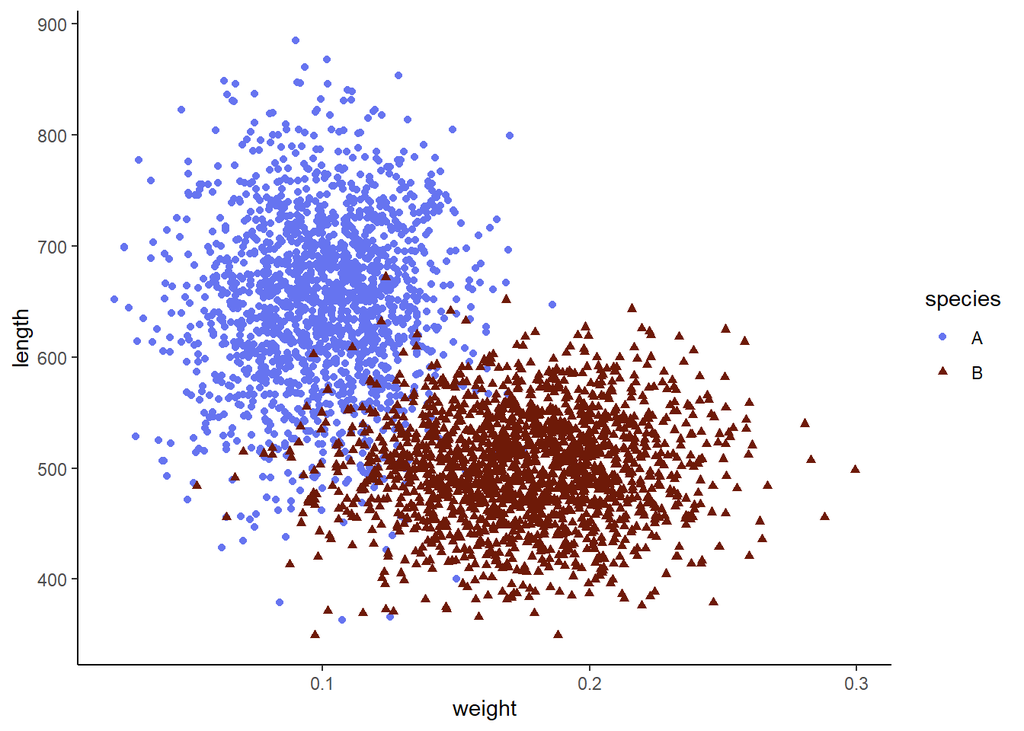

```r
ggplot(df.train, aes(x=weight, y=length, shape=species, color=species)) +
  geom_point() + theme_classic() +
  scale_color_manual(values = c("#6674f0", "#6e1a08"))
```

One thing that is apparent from this plot, is that our independent variables (i.e., weight and length) are on completely different scales. Here, weight is in kg, while length is in mm. [This is an issue for SVMs](https://stats.stackexchange.com/questions/65094/why-scaling-is-important-for-the-linear-svm-classification/224201), as if data is on different scales there is the potential for the numerically larger variables to be given a greater importance than the numerically smaller variables. This then has the potential to bias our model. As such, we need to rescale each variable to be on the same scale. This can be done with the following code, [see this stackoverflow link for more details](https://datascience.stackexchange.com/questions/13971/standardization-normalization-test-data-in-r). Note that the rescaling is first done on the train dataset, before the same rescaling is then applied to the test dataset. If the train and test datasets are rescaled independently then the testing of the model will be incorrect as the test and train datasets would not necessarily be comparable any more.

For this data, we are doing to center our data so that both length and weight are distributed around zero.

```r
#determine our rescaling based on the train dataset.
train_scaling <- preProcess(df.train, method=c("scale", "center"))

#rescale the train dataset
df.train <- predict(train_scaling, df.train)

#rescale the test dataset
df.test  <- predict(train_scaling, df.test)
```

We can then replot our train dataset using the following code.

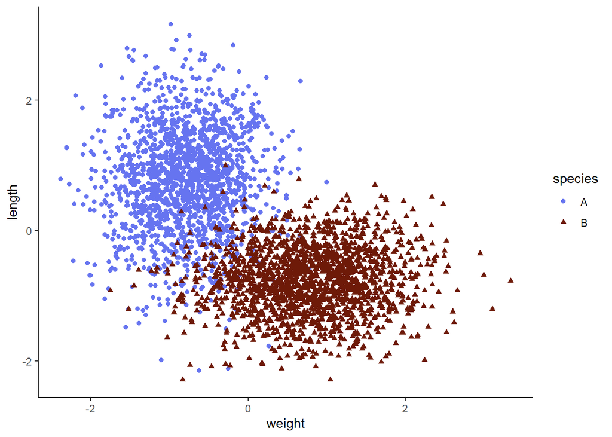

```r
ggplot(df.train, aes(x=weight, y=length, shape=species, color=species)) +
  geom_point() + theme_classic() +
  scale_color_manual(values = c("#6674f0", "#6e1a08"))
```

As we can see, the dataset has now been rescaled and centred around 0 for both the length and weight data. At this stage we can now proceed to training our SVM.

## Training the SVM

At this point we are now ready to start training our SVM. However, we have to make several decisions about our model. Firstly, we have to decide which kernel to use. There are many resources which discuss kernel choice, see links provided on the [initial page for support vector machines (SVMs)](https://benjburgess.github.io/svm).

For this introductory tutorial and we will be using a linear kernel.

The next decision we need to make is what values for the cost parameter we should specify. Fortunately, the SVM package we are using (`caret`) allows us to test various different parameter values and then select the best ones.

[Hsu et al. (2003)](https://www.csie.ntu.edu.tw/~cjlin/papers/guide/guide.pdf) advise that SVMs should be generated in two distinct sections. Firstly, a relatively coarse selection of parameter values should be selected which are used to train the model against the training dataset (i.e., training the model). At this point the best parameter values are identified. These parameter values are then used in the next stage (i.e., testing the model). For this tutorial, we are not going to be tuning our SVM, but instead using a cross-validation approach when training our SVM (see below).

The range of parameter values to be used is usually at the discretion of the user, although it is usually on a logarithmic scale. Hsu et al. (2003) suggest that values for cost could be $2^{-5}$, $2^{-3}$, … $2^{15}$. However, for this analysis we will be using cost parameter values of $2^{-2}$, $2^{-1}$, $2^{0}$, … $2^{7}$.

Following this, our SVM can be trained using the following code.

```r
#Choose the parameter values to search.
svm_grid <- expand.grid(C = 2^(-2:7))

svm_trained <- train(species ~.,
                     data = df.train,
                     method = "svmLinear",
                     trControl = trainControl(method="repeatedcv", number=10, repeats=3),
                     tuneGrid = svm_grid)

svm_trained
```

```
## Support Vector Machines with Linear Kernel
##
## 3500 samples
##    2 predictor
##    2 classes: 'A', 'B'
##
## No pre-processing
## Resampling: Cross-Validated (10 fold, repeated 3 times)
## Summary of sample sizes: 3150, 3150, 3150, 3150, 3150, 3150, ...
## Resampling results across tuning parameters:
##
##   C       Accuracy   Kappa
##     0.25  0.9624762  0.9249524
##     0.50  0.9622857  0.9245714
##     1.00  0.9622857  0.9245714
##     2.00  0.9626667  0.9253333
##     4.00  0.9624762  0.9249524
##     8.00  0.9623810  0.9247619
##    16.00  0.9624762  0.9249524
##    32.00  0.9624762  0.9249524
##    64.00  0.9622857  0.9245714
##   128.00  0.9622857  0.9245714
##
## Accuracy was used to select the optimal model using the largest value.
## The final value used for the model was C = 2.
```

```r
#show the summary of our svm training
```

At this stage, we now need to extract the best performing model using the following code.

```r
final_svm_model  <- svm_trained$bestTune
```

## Testing the SVM

So as we discussed above, the best forming model is where cost equals 2. Here across all 10 folds of the cross validation ~96.2666667% of our data points were assigned the correct species. This can be seen using the following code.

```r
svm_trained
```

```
## Support Vector Machines with Linear Kernel
##
## 3500 samples
##    2 predictor
##    2 classes: 'A', 'B'
##
## No pre-processing
## Resampling: Cross-Validated (10 fold, repeated 3 times)
## Summary of sample sizes: 3150, 3150, 3150, 3150, 3150, 3150, ...
## Resampling results across tuning parameters:
##
##   C       Accuracy   Kappa
##     0.25  0.9624762  0.9249524
##     0.50  0.9622857  0.9245714
##     1.00  0.9622857  0.9245714
##     2.00  0.9626667  0.9253333
##     4.00  0.9624762  0.9249524
##     8.00  0.9623810  0.9247619
##    16.00  0.9624762  0.9249524
##    32.00  0.9624762  0.9249524
##    64.00  0.9622857  0.9245714
##   128.00  0.9622857  0.9245714
##
## Accuracy was used to select the optimal model using the largest value.
## The final value used for the model was C = 2.
```

This analysis has so far been based on the training dataset, but at this stage we can now shift our attention to the test dataset we subset from the original data. Using our SVM we can now predict which species every data point corresponds to in the test dataset and compare our predictions to the actual species in this dataset. From this we can calculate various different metrics which we can use to assess the performance of our SVM. This can be done using the following code.

```r
pred=predict(svm_trained, df.test)

cm <- caret::confusionMatrix(pred, df.test$species)
#this uses the confusionMatrix function from the caret package
cm
```

```
## Confusion Matrix and Statistics
##
##           Reference
## Prediction   A   B
##          A 718  29
##          B  32 721
##
##                Accuracy : 0.9593
##                  95% CI : (0.9481, 0.9688)
##     No Information Rate : 0.5
##     P-Value [Acc > NIR] : <2e-16
##
##                   Kappa : 0.9187
##
##  Mcnemar's Test P-Value : 0.7979
##
##             Sensitivity : 0.9573
##             Specificity : 0.9613
##          Pos Pred Value : 0.9612
##          Neg Pred Value : 0.9575
##              Prevalence : 0.5000
##          Detection Rate : 0.4787
##    Detection Prevalence : 0.4980
##       Balanced Accuracy : 0.9593
##
##        'Positive' Class : A
##
```

There’s an awful lot of information here, so let’s breakdown piece by piece to assess our SVM.

Firstly, let’s start with the confusion matrix using the following code.

```r
cm$table
```

```
##           Reference
## Prediction   A   B
##          A 718  29
##          B  32 721
```

The confusion matrix is basically a way of allowing us to visually assess whether our SVM assigns species (from the test dataset) the correctly or, if not, where any errors are occurring. From our test data, we can see that our SVM broadly does a good job of determining species, with their being no obvious issues. Our data only contains two groups (i.e., species), however if we had multiple groups (i.e., species) then the confusion matrix may be more useful in determining where any potential errors are occurring.

Let’s move on to considering the overall statistics for our model, which can be called using the following code.

```r
cm$overall
```

```
##       Accuracy          Kappa  AccuracyLower  AccuracyUpper   AccuracyNull
##      0.9593333      0.9186667      0.9480660      0.9687530      0.5000000
## AccuracyPValue  McnemarPValue
##      0.0000000      0.7978939
```

So, of the metrics here, the main ones we are going to consider are accuracy and kappa.

If we start with accuracy, the accuracy of our SVM for the test dataset is 95.9333333% which is pretty similar to the accuracy we obtained from the k-fold cross validation of the SVM at the training stage. In other words, our SVM classifies the vast majority of our data points correctly. As such, our model does a really good job of classifying different species in our data.

The next metric to consider is the kappa value. The kappa value is an alternative measure of accuracy which considers the expected and observed accuracy of our SVM. I’m not going to explain kappa in any more detail (but see [this comprehensive explanation on stackoverflow](https://stats.stackexchange.com/questions/82162/cohens-kappa-in-plain-english)), but as with the accuracy metric the higher the value of kappa the better. As we can see, the measure of kappa for our analysis is 0.9186667. This value of kappa indicates that our SVM actually does a slightly worse job of correctly classifying species than is suggested by the SVM accuracy. However, this value is still very high and indicates that our SVM does a great job of classifying these species.

Overall, these metrics are two of the most commonly used metrics for assessing the performance of an SVM. However, additional metrics (e.g., specificity) that we aren’t going to consider here can be shown by using the following code.

```r
cm$byClass
```

```
##          Sensitivity          Specificity       Pos Pred Value
##            0.9573333            0.9613333            0.9611780
##       Neg Pred Value            Precision               Recall
##            0.9575033            0.9611780            0.9573333
##                   F1           Prevalence       Detection Rate
##            0.9592518            0.5000000            0.4786667
## Detection Prevalence    Balanced Accuracy
##            0.4980000            0.9593333
```

## Concluding remarks

Overall, our SVM does a great job of correctly classifying the two species in our dataset. In this example there is a relatively defined boundary between the two species, hence the SVM is able to very accurately classify our data. If there was not such a clearly defined boundary, then we might have difficulty in achieving such a high accuracy with our SVM. Similarly, if we had more than two species we may find that our SVM doesn’t do such a good job of classifying our data.

This introductory tutorial for SVMs uses a relatively straight-forward example with a very high accuracy for our model. However, this is not necessarily reflective of real-world data which is often much ‘messier’. As such, I have also put together an [advanced tutorial](https://benjburgess.github.io/i/SVM_radial) for a real-world dataset which uses an SVM to classify the quality of wines. This tutorial outlines various additional data cleaning approaches (e.g., SMOTE, SCUT, and dummy variables) that need to be considered. Similarly, this tutorial illustrates the potential ramifications of using SVMs when there is limited data which is ‘messy’ with no clearly defined boundaries between multiple (i.e., more than two) different classes or groups.

Overall, this has hopefully been an useful introductory example for Support Vector Machines!

## References

Hsu, C. W., Chang, C. C., & Lin, C. J. (2003). *A practical guide to support vector classification*.

## Links

[benjburgess.github.io](https://benjburgess.github.io/)

[Support Vector Machines](https://benjburgess.github.io/data/index/svm)